## STATS 763: Assignment 3: Is is worth throwing fish back?

#### 25/09/2024

The file `hopper.csv` comes from a study of the survival of under-sized fish that are caught by beam trawler commercial fishing boats and returned to the sea.

These fish live on or near the sea bottom. The study explored effects of observed environmental conditions at sea and of the randomly-assigned use of a water-filled storage hopper on the survival of the fish.

During trips with commercial trawlers, whole catches were unloaded from the net into either water-filled hoppers or conventional dry hoppers before sorting for size and species. For both hopper types, undersized fish were sampled from the sorting belt. After assessment of vitality status, sampled fish were housed in dedicated survival monitoring tanks on board. Upon return in the harbour fish were transferred to the laboratory to monitor their survival for up to 18 days post-catch.

The researchers recorded sea conditions such as wave height and water temperature, or obtained them from public data sources.

### Exploratory Analysis

#### Plots

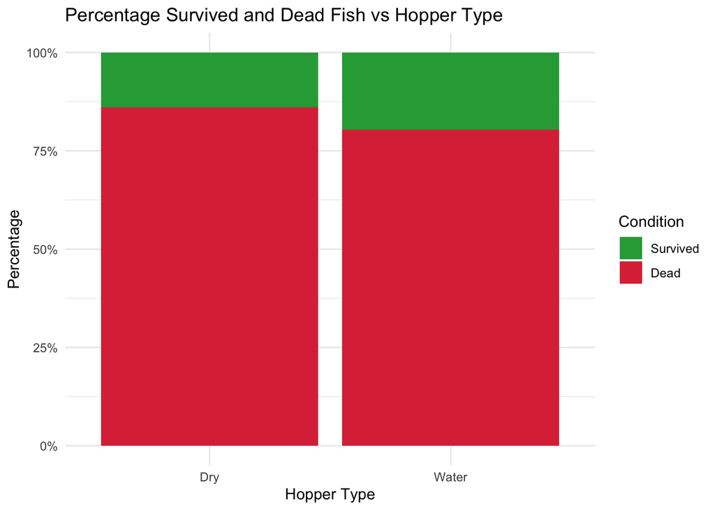

```r
ggplot(hopper, aes(fill=factor(Dead, levels = c(0, 1), labels = c("Survived", "Dead")), x=Hopper)) +
    geom_bar(position="fill") +
    scale_fill_manual(values = c("Survived" = "#28A745", "Dead" = "#DC3545")) +
    scale_y_continuous(labels = function(x) paste0(x * 100, "%")) +
    labs(x = "Hopper Type", y = "Percentage", title = "Percentage Survived and Dead Fish vs Hopper Type", fill = "Condition") +
    theme_minimal()
```

The average percentage of fish survival across all conditions seem to be less than 25%, with a slight increase in percentage of fish survival when fish are housed in a water-filled hopper. We must model with adjustments.

### 1. Which variables are potential confounders for the effect of hopper type on fish survival?

For a covariate to be a confounder of `Hopper` on fish survival (`Dead`), the cause (covariate) has to happen before the effect on hopper type. Since the study explored effects of the randomly-assigned use of water-filled storage hoppers or dry storage hoppers on the survival of the fish, there should be no confounders by design.

However, if we explored the effect of `Trip ID` on `Hopper`, the table shows that some trips have only dry hoppers. This could be due to the vessel not being compatible to have both a dry and water-filled hoppers. Certain trips will also have direct effects on fish survival probability. `Trip_ID` is therefore a confounder.

```
##
##         Dry Water
##   1ovl1  21     0
##   1ovl2  60     0
##   1ovl4  43     0
##   1ovl6  51     0
##   1ovl7  40     0
##   1ovlT  47     0
##   2olv1  60    60
##   2olv2  59    59
##   2olv3  60    60
##   2olv4  57    59
##   2olv5  80     0
##   2olv6  60    60
##   2olv7  60    60
##   2olv8  57    60
##   2olv9  59    60
```

### 2. Which variables are potential mediators of the effect of hopper type on fish survival?

For a covariate to be a mediator of `Hopper` on fish survival (`Dead`), `Hopper` needs to cause an effect on the covariate which in turn causes an effect on fish survival. Here are plausible mediators:

#### `Vitality Class`

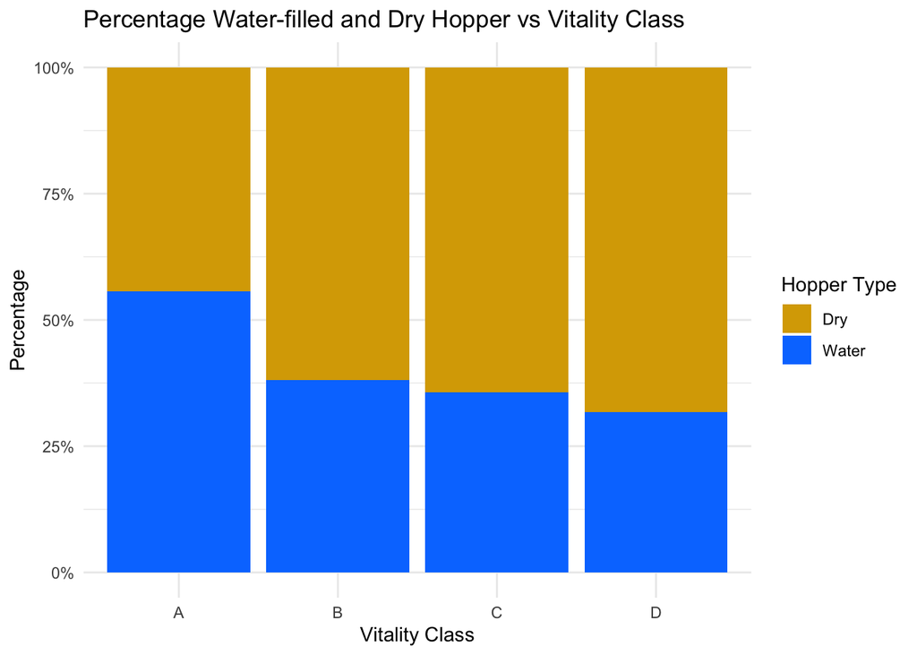

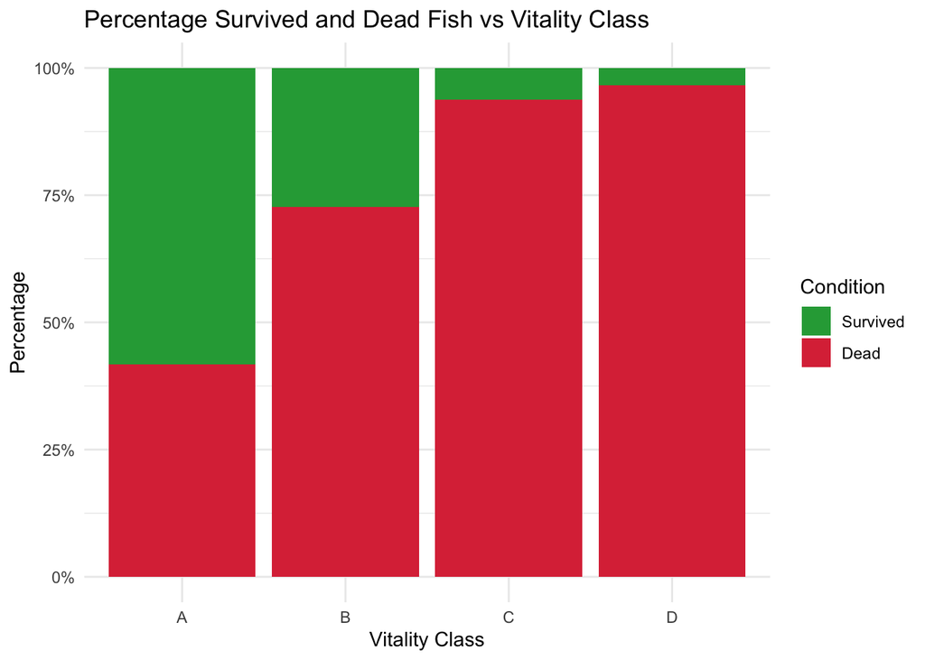

The stacked barplots show whether the fish is put in a dry or in water-filled hopper should have an effect on it’s vitality grade. The given vitality class also has an effect on the fish survival 18 days after being housed in a tank.

#### `Processing Time`

The time it takes for a fish to go from onboarding to storage tanks varies depending on whether they are placed in dry or water-filled hoppers. Longer processing times are expected to result in lower fish survival rates.

### 3. Estimate the effect of hopper type on survival.

```r
fish_survival_model <- glm(Dead ~ Hopper + Trip_ID, family = binomial(link = "logit"), data = hopper)
summary(fish_survival_model)
```

```
##
## Call:
## glm(formula = Dead ~ Hopper + Trip_ID, family = binomial(link = "logit"),
##     data = hopper)
##
## Deviance Residuals:
##     Min       1Q   Median       3Q      Max
## -2.9604   0.2829   0.5316   0.6426   0.9432
##
## Coefficients:
##              Estimate Std. Error z value Pr(>|z|)
## (Intercept)   1.16315    0.51235   2.270  0.02319 *
## HopperWater  -0.28735    0.17416  -1.650  0.09895 .
## Trip_ID1ovl2  0.02643    0.59638   0.044  0.96465
## Trip_ID1ovl4  0.86500    0.69915   1.237  0.21601
## Trip_ID1ovl6  2.03552    0.88482   2.300  0.02142 *
## Trip_ID1ovl7 -0.19375    0.62281  -0.311  0.75573
## Trip_ID1ovlT  1.95036    0.88585   2.202  0.02769 *
## Trip_ID2olv1  0.59684    0.57600   1.036  0.30012
## Trip_ID2olv2  0.24999    0.56644   0.441  0.65897
## Trip_ID2olv3  0.85989    0.58656   1.466  0.14265
## Trip_ID2olv4  1.59456    0.63780   2.500  0.01242 *
## Trip_ID2olv5  3.20629    1.12831   2.842  0.00449 **
## Trip_ID2olv6  0.37301    0.56895   0.656  0.51207
## Trip_ID2olv7  0.72234    0.58070   1.244  0.21353
## Trip_ID2olv8  0.76347    0.58406   1.307  0.19116
## Trip_ID2olv9 -0.29624    0.55615  -0.533  0.59426
## ---
## Signif. codes:  0 '***' 0.001 '**' 0.01 '*' 0.05 '.' 0.1 ' ' 1
##
## (Dispersion parameter for binomial family taken to be 1)
##
##     Null deviance: 1140.3  on 1291  degrees of freedom
## Residual deviance: 1061.8  on 1276  degrees of freedom
## AIC: 1093.8
##
## Number of Fisher Scoring iterations: 6
```

```r
est <- tidy(fish_survival_model)$estimate[2]
variance <- tidy(fish_survival_model)$std.error[2]^2
variance_delta = exp(2*est) * variance^2

ci_lower <- exp(est) - 1.96 * sqrt(variance_delta)
ci_upper <- exp(est) + 1.96 * sqrt(variance_delta)

ci <- c(ci_lower, exp(est), ci_upper)
names(ci) <- c("2.5%", "Estimate", "97.5%")
ci <- 1 - ci
ci
```

```
##      2.5%  Estimate     97.5%
## 0.2943494 0.2497489 0.2051484
```

### 4. How does the effect of hopper type on survival vary with fish characteristics and sea conditions?

Introduce interaction term with hopper type and fish characteristics and sea conditions.

```r
fish_survival_interaction_model <- glm(Dead ~ Trip_ID + Hopper*(Temp_water + Wave_height + Haul_duration + Substrate + Length), family = binomial(link = "logit"), data = hopper)
summary(fish_survival_interaction_model)
```

```
##
## Call:
## glm(formula = Dead ~ Trip_ID + Hopper * (Temp_water + Wave_height +
##     Haul_duration + Substrate + Length), family = binomial(link = "logit"),
##     data = hopper)
##
## Deviance Residuals:
##     Min       1Q   Median       3Q      Max
## -3.2743   0.2737   0.5205   0.6279   1.2889
##
## Coefficients:
##                                         Estimate Std. Error z value Pr(>|z|)
## (Intercept)                             7.337384   7.502437   0.978   0.3281
## Trip_ID1ovl2                           -3.653240   3.949350  -0.925   0.3550
## Trip_ID1ovl4                           -1.021864   2.568384  -0.398   0.6907
## Trip_ID1ovl6                            1.770738   1.197357   1.479   0.1392
## Trip_ID1ovl7                            1.117370   1.158975   0.964   0.3350
## Trip_ID1ovlT                            2.862706   1.260985   2.270   0.0232 *
## Trip_ID2olv1                           -1.185887   2.063235  -0.575   0.5654
## Trip_ID2olv2                           -0.765429   1.356197  -0.564   0.5725
## Trip_ID2olv3                            0.703458   0.828057   0.850   0.3956
## Trip_ID2olv4                            3.622785   2.590798   1.398   0.1620
## Trip_ID2olv5                            4.506470   2.058015   2.190   0.0285 *
## Trip_ID2olv6                            0.381299   0.784611   0.486   0.6270
## Trip_ID2olv7                           -0.411988   1.562839  -0.264   0.7921
## Trip_ID2olv8                           -2.752031   3.851856  -0.714   0.4749
## Trip_ID2olv9                           -4.853306   4.739351  -1.024   0.3058
## HopperWater                             0.823423   4.443100   0.185   0.8530
## Temp_water                             -0.439245   0.449660  -0.977   0.3286
## Wave_height                            -0.002967   0.003558  -0.834   0.4044
## Haul_duration                           0.024270   0.032269   0.752   0.4520
## SubstrateMud to muddy Sand             -0.140059   0.896964  -0.156   0.8759
## SubstrateSand                          -1.035837   0.581194  -1.782   0.0747 .
## Length                                 -0.067128   0.042122  -1.594   0.1110
## HopperWater:Temp_water                  0.049508   0.045148   1.097   0.2728
## HopperWater:Wave_height                 0.006275   0.003679   1.706   0.0881 .
## HopperWater:Haul_duration              -0.024341   0.036201  -0.672   0.5013
## HopperWater:SubstrateMud to muddy Sand  1.666805   1.192297   1.398   0.1621
## HopperWater:SubstrateSand               0.897747   0.692574   1.296   0.1949
## HopperWater:Length                     -0.013432   0.061200  -0.219   0.8263
## ---
## Signif. codes:  0 '***' 0.001 '**' 0.01 '*' 0.05 '.' 0.1 ' ' 1
##
## (Dispersion parameter for binomial family taken to be 1)
##
##     Null deviance: 1140.3  on 1291  degrees of freedom
## Residual deviance: 1038.3  on 1264  degrees of freedom
## AIC: 1094.3
##
## Number of Fisher Scoring iterations: 6
```

For evaluating interaction terms, we look at the p-values for the coefficients of interest. Large p-values; greater than 0.05 for `Hopper`, `Hopper:Sea condition` and `Hopper:fish characteristics` coefficients indicate there is insignificant evidence to suggest that estimates for `Hopper` vary with fish characteristics and sea conditions.

### 5. To what extent would measuring vitality class (which is rapid and simple) be a good substitute for measuring actual fish survival (which is slow and expensive)?

Fit a model for `Vitality_class` on fish survival. We include `Hopper` and `Trip_ID` as confounders.

```r
test_model <- glm(Dead ~ Vitality_class + Hopper + Trip_ID - 1, family = binomial(link = "logit"), data = hopper)
summary(test_model)
```

```
##
## Call:
## glm(formula = Dead ~ Vitality_class + Hopper + Trip_ID - 1, family = binomial(link = "logit"),
##     data = hopper)
##
## Deviance Residuals:
##     Min       1Q   Median       3Q      Max
## -2.7336   0.1225   0.2746   0.4872   2.2287
##
## Coefficients:
##                 Estimate Std. Error z value Pr(>|z|)
## Vitality_classA -0.37640    0.61244  -0.615  0.53883
## Vitality_classB  1.15366    0.60708   1.900  0.05739 .
## Vitality_classC  3.11544    0.63641   4.895 9.81e-07 ***
## Vitality_classD  4.09142    0.68408   5.981 2.22e-09 ***
## HopperWater      0.03637    0.20479   0.178  0.85905
## Trip_ID1ovl2    -1.19669    0.70280  -1.703  0.08861 .
## Trip_ID1ovl4    -0.27915    0.79766  -0.350  0.72637
## Trip_ID1ovl6     1.29065    0.96433   1.338  0.18077
## Trip_ID1ovl7    -1.13935    0.72953  -1.562  0.11834
## Trip_ID1ovlT     0.79667    0.97442   0.818  0.41360
## Trip_ID2olv1     0.28816    0.66478   0.433  0.66467
## Trip_ID2olv2    -0.74892    0.67017  -1.117  0.26378
## Trip_ID2olv3    -0.13074    0.68215  -0.192  0.84801
## Trip_ID2olv4     1.29416    0.73016   1.772  0.07632 .
## Trip_ID2olv5     2.55860    1.18188   2.165  0.03040 *
## Trip_ID2olv6    -0.28381    0.66131  -0.429  0.66781
## Trip_ID2olv7    -0.50945    0.67386  -0.756  0.44963
## Trip_ID2olv8     0.10763    0.67404   0.160  0.87313
## Trip_ID2olv9    -2.02001    0.67618  -2.987  0.00281 **
## ---
## Signif. codes:  0 '***' 0.001 '**' 0.01 '*' 0.05 '.' 0.1 ' ' 1
##
## (Dispersion parameter for binomial family taken to be 1)
##
##     Null deviance: 1791.09  on 1292  degrees of freedom
## Residual deviance:  797.94  on 1273  degrees of freedom
## AIC: 835.94
##
## Number of Fisher Scoring iterations: 7
```

### Discussions

- Sampling based on length, possible confounder?
- putting them in a tank could be problematic
- Experiment